# Student’s t-Distribution

Core Concepts, Source Comparisons, and Practical Insights

2026-09-30

## 1. Executive Overview

- **The Core Purpose**:
  - Designed for population mean inferences when true population variance ($\sigma^2$) is unknown.
  - Replaces standard normal $Z$-distribution when estimating spread from small samples.
- **Historical Origins**:
  - Formulated by chemist **William Sealy Gosset** in 1908.
  - Published under the famous pseudonym **“Student”** while at Guinness Brewery.

## 2. Fundamental Mathematical Properties

- **Definition & Statistic**:
  - Calculated as $t = \frac{\bar{x} - \mu}{s / \sqrt{n}}$ for samples from normal populations.
  - Uses sample standard deviation ($s$) to estimate unknown population standard deviation ($\sigma$).
- **Key Geometric Traits**:
  - **Symmetrical**: Perfectly balanced around a mean of zero.
  - **Continuous**: Spans infinitely from $-\infty$ to $+\infty$.
  - **Heavier Tails**: Less peaked at the center with thicker tails than the $Z$-distribution.
  - **Wider Critical Values**: Thicker tails adjust for small-sample sampling uncertainty.
- **Variance & Degrees of Freedom**:
  - Governed by **degrees of freedom** ($df = n - 1$).
  - Variance exceeds 1: Calculated as $\frac{df}{df - 2}$ for $df > 2$ (or $\frac{n - 1}{n - 3}$ for $n > 3$).
  - **Convergence**: Approaches the standard normal $Z$-distribution as $df \to \infty$.

## 3. Practical & Clinical Perspectives

- **Small-Sample Adjustment**:
  - $Z$-distribution approximations degrade as sample sizes shrink.
  - Inflates critical thresholds to prevent false positive conclusions.
- **Degrees of Freedom Mechanics**:
  - Calculated as $df = n - 1$.
  - 1 degree of freedom lost because sample mean fixes central position.
  - Analogy: Like fence post gaps—fixing the mean leaves $n - 1$ independent values.
- **Operational Rules & Reporting**:
  - **Preferred**: Highly recommended for sample sizes $n < 60$.
  - **Essential**: Critical for small samples with $n \le 30$.
  - **Avoid Dichotomania**: Rejecting rigid $P \le 0.05$ pass/fail cutoffs.
  - **Complete Reporting**: Always report $t$-statistic, $df$, $P$-value, and 95% Confidence Intervals together.

## 4. Visualizing the $t$-Distribution vs. $Z$-Distribution

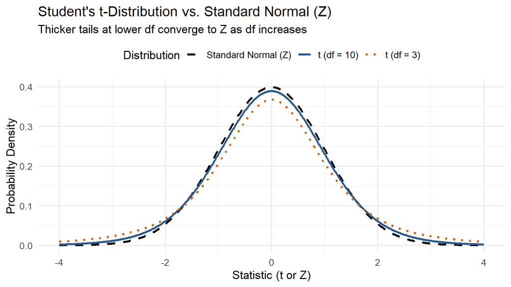

## 5. Summary

- **t distribution is**:
  - A mathematical tool for analyzing small groups of data.
  - Solves the problem of unknown population spread.
- **How it works**:
  - Has a flatter top and wider sides (thicker tails) than a normal bell curve.
  - Wider tails inflate critical boundaries, preventing false conclusions from small samples.
- **The Magic of Sample Size**:
  - Curve shape is controlled by **degrees of freedom** ($df = n - 1$).
  - As sample size grows, extra uncertainty fades away.
  - The $t$-distribution transforms until it perfectly matches the standard normal bell curve.

## 6. R Computation

```
# 1. Calculating Critical t-Value for 95% Confidence (df = 29)
qt(p = 0.975, df = 29)
[1] 2.04523
# 2. Calculating Two-Tailed P-Value for t = 2.15 (df = 18)
2 * (1 - pt(q = 2.15, df = 18))
[1] 0.04539693
# 3. Running a One-Sample t-Test in R
# t.test(x = sample_data, mu = hypothesized_mean)
```

## References

- Daniel, W. W., & Cross, C. L. *Biostatistics: A Foundation for Analysis in the Health Sciences* (10th ed.) .
- Campbell, M. J. *Statistics at Square One* (12th ed.).